# Review #1

Yen-Chung Chen

2022-10-11

## R Syntax

### Concepts to grasp

- Importing data
- Getting columns, rows, and elements from an object
- Arithmetic with R
- Loops and conditional statements
- Defining functions
- Basic plotting
  - Histogram
  - Bar plot
  - Scatter plot
  - Box plot
1. Load `penguins.csv` and `penguins.tsv` into R as two objects named `pen_csv` and `pen_tsv`. Are the two files the same? If not, please describe their differences.

```r
# Consider using read.csv() or read.table() and check the arguments that you
# might need to adjust
```

2. How many rows and columns do `pen_csv` and `pen_tsv` have?
3. Calculate the arithmetic mean of column `body_mass_g` from `pen_csv`. Ignore possible missing data.

$$A = \frac{\sum^n_{i =
1}X_{i}}{n}$$

```r
# There is a built-in function for arithmetic mean in R
```

4. Calculate the geometric mean of column `bill_depth_mm` ignoring possible missing data.

$$G = \sqrt[n]{\Pi^n_{i =
1}X_{i}}$$

5. Define a function, `harmonicmean()`, that takes a numeric vector and calculate its harmonic mean.

$$H= \left(
\frac{\sum^n_{i=1}\frac{1}{X_i}}{n} \right)^{-1}$$

```r
harmonicmean = function(x) {
  # Calculation here
}
```

6. Use a for loop and `harmonicmean()` you just defined above to calculate the harmonic mean from column 3 (`bill_length_mm`) to 6 (`body_mass_g`).
7. An absolute value is defined as follows:

$$\begin{equation}
|x|= \left\{
\begin{array}{@{}rl@{}}
x &\text{ if } x \ge 0 \\
-x &\text{ if } x < 0
\end{array}
\right .
\end{equation}$$

Please define a function, `myabs()` with an if statement.

```r
# If statements take the following form:
# if (condition) {
#   # The code that would only be run when condition is TRUE
# } else {
#   # The code that would only be run when condition is FALSE
# }
```

8. Use a histogram with 30 bins to visualize the distribution of bill length of the penguins (column `bill_length_mm`)
9. Use a barplot to show the number of penguins of each species

```r
# You might want to use table() and barplot()
```

10. Use boxplot to visualize if body mass differs between species

## Counting and set manipulation

1. How many penguins in `pen_csv` came from each of the three islands respectively? (Hint: You did something similar in question #9 in the previous section)
2. Given two vector `x` and `y` where $x = x_1, x_2, ..., x_n$ and $y = y_1, y_2, y_3,...,y_n$. How many pairs of $(x, y)$ satisfy $x^2+y^2 \le 1$?

```r
# It does not matter, but this is also known as estimating Pi with two uniform
# random variables.
set.seed(1011)
x = runif(1000, min = -1, max = 1)
y = runif(1000, min = -1, max = 1)
```

3. There is two bag of balls. The first bag contains one blue, one black, and one pink ball while the second bag contains one blue, one white, and one violet ball. Define two vectors, `bag1` and `bag2` to represent all the possible outcomes of drawing 1 ball from bag #1 and bag #2 respectively.
4. What is the union of outcomes from bag1 and bag2 ($bag_{1} \cup bag_{2}$)? How many elements are there?
5. What is the intersection of outcomes from bag1 and bag2 ($bag_{1} \cap bag_{2}$)? How many elements are there?
6. Are possible draws from bag1 and bag2 disjoint? If they are not, remove a ball from bag1 to make them disjoint.
7. Which of the following are true?
   1. If $A \cap B = B$, then $B \subset A$
   2. If $A \cup B = B$, then $B \subset A$
   3. If $A \cup B = B$, then $B \supset A$
   4. If $A \cap B = B$, then $B \supset A$

## Probability and combinatorics

1. There are 20 amino acids that human use to make proteins. How many different kind of peptides that are 8 amino acid long are there?
2. Given that you roll a fair six-sided dice twice, how many outcomes are there that makes a sum of 5 if order matters? List them out.
3. How many possible outcomes are there for two rolls of a six-sided dice?
4. What is the probability of getting a total of 5 from two rolls of a six-sided dice? Note that *if the probability of all outcomes are the same*, you can say $P(sum = 5) = \frac{N(sum = 5)}{N(all \; outcomes)}$ where $N$ is the number of outcomes that fulfill the specified criteria.
5. Given $P(A) = 0.7$, $P(B) = 0.5$, and $P(A \cap B) = 0.2$, what is $P(A \cup B)$?
6. In the previous question, are A and B independent? Why?
7. Assume you are playing a game where the award is randomly placed behind three doors, what is the probability of you guessing it right and picking the door with an award behind it?
8. Assuming that after you picked a door, a door that you did not choose and is empty will be opened. What is the probability of winning if you (a) don’t change your choice? (b) picked the other unopened door?
9. You invented a test kit for disease X. When testing the kit on positive samples from confirmed patients, the kit will turn out positive 95% of the time. While tested on negative samples from confirmed healthy people, the same test kit turn out negative 98% of the time. Now, you want to deploy your kit to an area where it is estimated that 5% of the people are infected. If you get a positive result in that area, how likely is the subject being tested is really infected? (Hint: Bayes theorem)
10. Given a bag with 47 black balls and 3 white balls, what is the chance of getting a black ball if you are the first to draw from the bag?
11. If the balls are not put back to the bag, what is the probability of you getting a white ball if you are the second to draw given the first person (a) have gotten a white ball (b) have gotten a black ball?
12. In the previous question, if you are the second person to draw, is your drawing from the bag independent from the first person’s draw? Explain why.

## Random variables and distributions

1. Explain what is a discrete random variable.
2. Explain what is a continuous random variable.
3. Explain what is probability density and how density is different from probability itself.
4. Assume a basket ball player has **59.7% chance** to hit from the free-throw line, what is the probability of this person hit two and miss one in **three free throws**?
5. Assume systolic pressure of healthy people is normally distributed (**mean = 105 mmHg, sd = 12mmHg**). You met a patient in the clinic with systolic pressure of 130mmHg. How likely a healthy person to manifest a systolic pressure > 130mmHg by pure chance?
6. My car broke down during a road trip in the middle of nowhere. For whatever reason, I know there is on average **one car passing by per 3 hour**. Assuming everyone is very nice and will let me hitchhike when they meet me, what is the chance that I have to wait for more than 4 hours?
7. A flush in poker is a hand containing five cards from the same suit. If you are the first to draw 5 cards, what is the chance of you getting a flush of spades from **a deck of poker with 2 joker cards**? (Including straight flush and royal flush, where the cards are not only from the same suit but also of sequential rank).
8. You are working with a standard normal distribution in which **mean = 0 while standard deviation = 1**. What is the value that would be higher than 97.5% of the observations in the distribution? What is the value that would be lower than 97.5% of the observations in the distribution?

## Working with samples

### Parameters

Parameters are numbers that summarize data. There are in principle three types of parameters:

- Location: How large/small the values are.
- Scale: How spread out/variable the values are.
- Shape: Other things that are neither location nor scale (i.e., symmetry)

#### Questions

1. Name two location parameters and how they are calculated from data.
2. Name two scale parameters and how they are calculated from data.

### Sample and bias

Oftentimes, we cannot exhaustively observe everything in the population, and estimation from a sample becomes a must. Due to various sources of uncertainty (e.g., biological variations and measurement errors), one can only estimate parameters from samples.

1. Sample variance is defined as $S^2 = \frac{\sum^{n}_{i = 1}(X_i - \overline{X})^2}{n - 1}$. The denominator (n - 1) is called *degree of freedom* and is derived to make sure that sample variance is an unbiased estimator of population variance. Sample a size of 3 from a normal distribution (mean = 5 and variance ($\sigma^2$) = 4), and calculate the sample variance with the formula above. Repeat the above process with sample size of 5, 10, 20, 50, 100, 1000. Plot the simulated result and described it. Is it consistent with $S^2$ being an unbiased estimator of $\sigma^2$? Why?

```r
sample_size = c(3, 5, 10, 20 , 50, 100, 1000)
```

2. Now, perform the same simulation but define sample variance as $S^\prime{}^2 = \frac{\sum^{n}_{i = 1}(X_i - \overline{X})^2}{n}$. Is $S^\prime{}^2$ an unbiased estimator of $\sigma^2$? Why?

### Sample distributions

Combining proper parameters and known types of distributions can often give way more information than knowing the parameters alone, but to use distributions as we did previously in section *random variables and distributions*, we often need parameters at population level (parts with bold font in questions in section *random variables and distributions*). However, the inability to learn population parameters is often the reason why you need statistics at the first place.

Luckily, several distributions were derived to represent various parameters estimated from a sampling process.

- chi-square distribution is the distribution of $S^2 \times (k - 1)$ of a sample from a standard normal distribution. That is, if you sample k numbers from a standard normal distribution, the sample variance will obey a chi-square distribution with degree of freedom = k - 1.
- t distribution with a degree of freedom of k - 1 is the distribution of $\frac{\overline X - \mu}{\frac{S}{\sqrt{k}}}$ if $X_i$ is sampled from a normal distribution. The above equation is also called the *t-statistic*.
- F distribution with a degree of freedom of k is the distribution of the ratio of $\frac{S^2}{df}$ from two samples coming from normal distributions. That is, $F = \frac{S_1^2}{S_2^2}$
1. Define confidence interval.
2. Given a normal distribution with mean = 5 and standard deviation = 3, if you have a sample from that distribution, what is the 95% confidence interval of the population mean?

```r
sample_x = c(7.887091, 2.484197, 10.948158)
```

3. Sample n = 3 from a normal distribution with mean = 5 and standard deviation = 3 for 10,000 times, and calculate the 95% confidence interval every time. How many times does the confidence interval contains 5?

```r
# Hint: Use a for loop
```

4. Assume you have a sample n = 3 from a normal distribution with mean = 5 and standard deviation = 3. Pretend you don’t know the *real (population) mean and standard deviation*, what is the 95% confidence interval of the population mean.

```r
# Hint: t distribution
sample_x = c(7.887091, 2.484197, 10.948158)
```

5. Sample n = 3 from a normal distribution with mean = 5 and standard deviation = 3 for 10,000 times, pretend you don’t know the _real (population) mean and standard deviation_and calculate the 95% confidence interval every time. How many times does the confidence interval contains 5?

### Bootstrapping

Sometimes, we cannot safely assume the type of population we got our sample from. As a result, the previous calculation for confidence interval will not work. However, if we have a large enough sample size, we might be able to assume the sampling distribution will be similar to re-sampling distribution.

In this case, while we don’t have access to functions like `qt()` or `qnorm()`, we can use `quantile()` on the resampled distribution.

1. Sample n = 500 from a normal distribution with mean = 5 and standard deviation = 3. Pretend that we don’t know what is the nature of the distribution our sample is from. Use `sample()` with `replace = TRUE` to resample a size of 300 for 1,000 times, and get the value at the 2.5% and 97.5% quantile. Compare these values with the 95% confident interval calculated knowing that the samples are from $N(5, 3)$. Are they similar?

```r
set.seed(1234)
sample_bs = rnorm(500, 5, 3)
```

### Central limit theorem

Central limit theorem states that: *if the sample size is sufficiently large, the distribution of sample mean will be normally distributed*.

1. Sample 100 times from a beta distribution with shape1 = shape2 = 0.5 with size = 1, 3, 10, 15, 30, 50. Make a qqplot to compare with a normal distribution with `qqnorm()`. Describe what you see. Is this consistent with the central limit theorem?

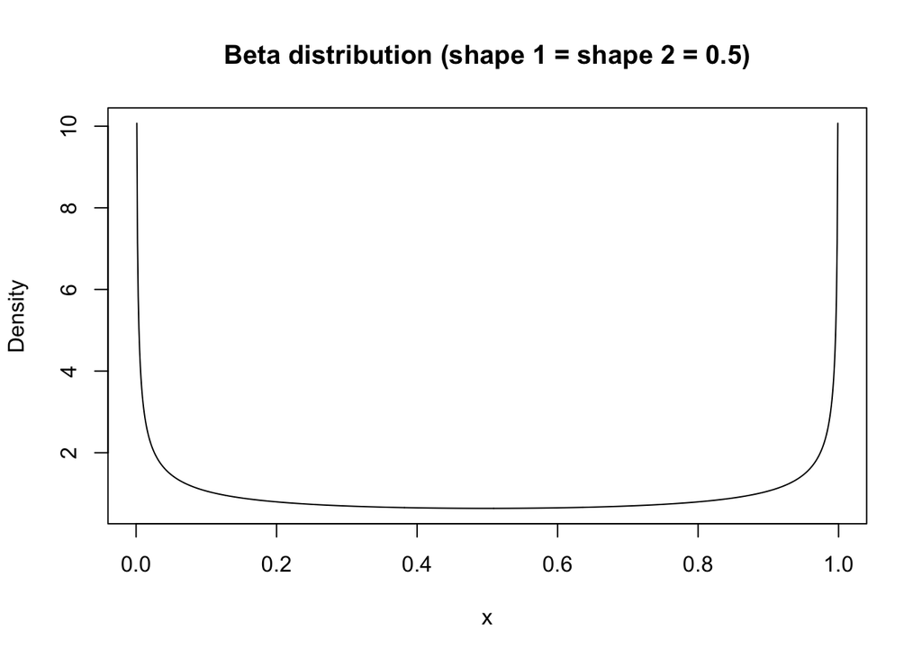

```r
sample_size = c(1, 3, 10, 15, 30, 50)
```